# Chapter 7 Notes

Jack Nystrom

AP Chemistry

**Chapter 7 Notes - Atomic Structure and Periodicity**

**Electromagnetic Radiation**: one of the ways that energy travels through space. Examples are the light from the sun (visible light), the energy used to cook food in a microwave, X-rays, and radiant heat from a fireplace. They all exhibit wavelike behavior and travel at the speed of light in a vacuum.

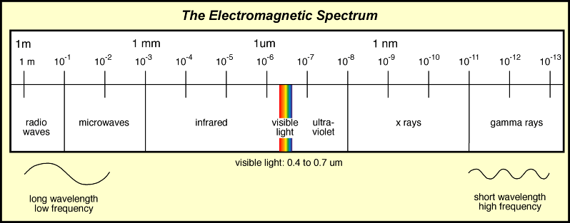

**Planck’s Constant**: h = 6.626 * 10^-34 J*s. Planck postulated that energy can be gained or lost only in *whole-number multiples* of the quantity *hv*, with v being the frequency of the electromagnetic radiation absorbed or emitted. *ΔE = nhv*

Key for understanding waves: Velocity = Wavelength * Frequency.

This result was surprising, as energy was always assumed to be continuous, but this showed that it was quantized. Each of these small packets of energy is called a **quantum**. A system can only transfer energy in whole quanta;” thus energy seems to have particulate properties.

Einstein then suggested that electromagnetic radiation is itself quantized, and can be viewed as a stream of **Photons**. The energy of each photon is given by: *E<sub>photon</sub> = hv = hc/𝝀*, where h is planck’s constant, *v* is the frequency of radiation, c is the speed of light, and *𝝀* (lambda) is the wavelength of the radiation.

The **Photoelectric Effect**: the phenomenon in which electrons are emitted from the surface of a metal when light strikes it. Characteristics:

1. No electrons are emitted by a given metal below a specific threshold frequency, v<sub>0</sub>. (regardless of the intensity of the light)
2. For light with frequency greater than the threshold frequency, the number of electrons emitted increases with the intensity of the light.
3. For light with frequency greater than the threshold frequency, the kinetic energy of the electrons emitted increases linearly with the frequency of the light.

This can be explained knowing that electromagnetic radiation is quantized (photons) and that the threshold frequency represents the minimum energy required to remove the electron from the metal’s surface.

KE<sub>electron</sub> = ½mv^2 = E<sub>photon</sub> - E<sub>required</sub> = h*v* - h*v*<sub>0</sub>, because h*v* is the energy of the incident photon and h*v*<sub>0</sub> is the energy required to remove the electron from the metal’s surface (*v*<sub>0</sub> is the threshold frequency).

Assuming E = mc^2 => m = E/c^2 (Einstein’s equation from his theory of general relativity),

as well as E<sub>photon</sub> = h*v* = hc/𝝀 from above, we get this equation for the mass of a photon:

m<sub>photon</sub> = h / 𝝀c.

Interestingly, rearranging this equation (while substituting c, the speed of light, for v, the speed of a given particle) gives us the theoretical wavelength of any particle!:

𝝀 = h / m<sub>particle</sub>v (which is called de Broglie’s equation)

This calculatable value for the mass of photons was proven experimentally, but it’s clear that photons don’t have mass in the classical sense (the book calls it only in “the relativistic sense”).

**Dual Nature of Light**: the phenomenon that light (electromagnetic radiation) exhibits characteristics of both particulate matter and waves.

**Diffraction**: when light is scattered from a regular array of points or lines (eg. light shining through a prism, CD disks).

All matter exhibits both particle and wave properties. Large matter, such as baseballs, exhibit predominantly particulate properties, whereas small matter, such as photons, exhibit predominantly wave properties. Electrons, with “intermediate” mass, clearly exhibit properties of both; they have experimentally measurable wavelengths and mass.

When a sample of hydrogen receives a high-energy spark, the H2 molecules absorb energy, and some of the H-H bonds are broken. The resulting hydrogen atoms are *excited*; that is, they contain excess energy, which they release by emitting light of various wavelengths - what is called the *emission spectrum* of the hydrogen atom.

**Continuous Spectrum**: the emission spectrum that is produced when white light is passed through a prism. It contains *all* wavelengths of visible light. In contrast, the hydrogen emission spectrum, when passed through a prism, produces only a few discrete lines, each corresponding to a specific wavelength. This is called a **Line Spectrum**.

The hydrogen emission spectrum essentially shows that the energy of the electron in the hydrogen atom is quantized, because only certain energies are allowed for it.

**Ground State**: the lowest possible energy state of an atom.

**The Bohr Model** (which only works for hydrogen) postulates that the electron in a hydrogen atom moves around the nucleus only in certain allowed circular orbits. This model led to the following equation for the *energy levels available to the electron in the hydrogen atom:*

E = (-2.178 * 10^-18 J) * (Z^2 / n^2), where Z is the nuclear charge and n is an integer (the larger n, the larger the orbit radius).

This equation can be used to find the change in energy of an electron when it changes orbits:

ΔE = E<sub>f</sub> - E<sub>i</sub> = (-2.178 * 10^-18 J) * (Z^2 / n<sub>f</sub>^2 - Z^2 / n<sub>i</sub>^2)

The loss of energy accompanied by an electron moving to a lower energy level is carried away by the emission of a proton. The frequency (v) of said proton can be calculated using the equation from above: *E<sub>photon</sub> = ΔE = hv = hc/𝝀*, or *𝝀 = hc/ΔE*

**Standing Wave**: A stationary wave. For example, the strings of a guitar; the vibrations do not travel down the length of the string.

**Heisenberg Uncertainty Principle**: *There is a fundamental limitation to just how precisely we can know both the position and momentum of a particle at a given time.* Mathematically, the uncertainty formula shows that the more precisely we know a particle’s position, the less certain we can be of its momentum, and vice versa. It is therefore not appropriate to assume that the electron is moving around the nucleus in a well-defined orbit, as in the Bohr model.

Each atomic orbital corresponds to a wave function which can be applied to Schrodinger’s equation. An atomic orbital does not specify where an electron is within an atom, but rather the probabilities of finding the atom at each position around the nucleus of the atom.

Quantum Numbers:

- Principal quantum number (n) - an integer - size and energy of the orbital. As n increases, the orbital size increases and so does the energy (as the electron spends more time farther from the nucleus). Picture adding energy to an atom makes electrons jump up (high energy).
- Angular momentum quantum number (ℓ/l) - integral values from 0 to n-1 - shape of the atomic orbitals.
- Magnetic quantum number (m<sub>l</sub>) - integral values from -ℓ to ℓ - orientation of the orbital relative to the other orbitals in the atom.
- Electron spin quantum number (m<sub>s</sub>) - either +½ or -½ - spin direction of the electron (interpreted to mean that the electron can have one of two opposite spin directions). Discovered later when researchers found that the first 3 Q.N.s couldn’t account for spin.

Orbitals’ values of ℓ are typically assigned letters:

ℓ = 0: s = 1 orbital

ℓ = 1: p = 3 orbitals

ℓ = 2: d = 5 orbitals

ℓ = 3: f = 7 orbitals

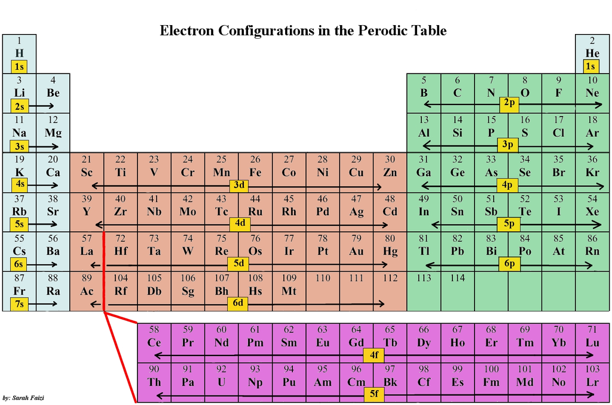

Sublevel designations (1s, 6d, 3p, etc) are the value of n followed by the letter for ℓ.

All orbitals with the same value of n have the same energy - they are said to be **degenerate**.

**Pauli exclusion principle**: In a given atom no two electrons can have the same set of four quantum numbers (n, ℓ, m<sub>ℓ</sub>, m<sub>s</sub>). Since electrons in the same orbital have the same values of n, ℓ, and m<sub>ℓ</sub>, this states that *each orbital can only hold two electrons, which must have opposite spins*.

All of the above principles apply to atoms with more than one electron ( >H ), but it becomes tricky and impossible to solve precisely as the interactions (repulsions) between electrons add to the energy of the atom and cannot be known as the positions of the electrons also cannot be known.

One key difference is that unlike hydrogen, for which all of the orbitals in a given principal quantum level have the same energy level, polyelectronic atoms’ orbitals for a given principal quantum level vary in energy. (E<sub>ns</sub> < E<sub>np</sub> < E<sub>nd</sub> < E<sub>nf</sub>)

**Aufbau principle**: As protons are added one by one to the nucleus to build up the elements, electrons are similarly added to these hydrogen-like orbitals.

**Hund’s rule**: The lowest energy configuration for an atom is the one having the maximum number of unpaired electrons allowed by the Pauli principle in a particular set of degenerate orbitals. (i.e. for 2p orbitals, of which there are three, start by filling them one by one with 1 electron spinning up, then go back to the first and fill the second electron spinning down.)

**Valence electrons**: the electrons in the outermost principal quantum level of an atom.

For N (1s2, **2**s2, **2**p3), the electrons in the n=**2** quantum level are the valence electrons.

IMPORTANT OBSERVATION TIME!! (look at the table image on the last page):

The elements in the same group (vertical column) on the periodic table have the same valence electron configuration. Furthermore, each row in the periodic table corresponds to one principle quantum number, n.

**First ionization energy**: the energy required to remove the highest-energy electron from an atom.

**Electron affinity**: the energy change associated with the addition of an electron to a gaseous atom.

**Electronegativity**: The tendency of an atom to attract electrons to itself. I.e., the electronegativity of an atom is how much that atom wants more electrons.